# Police Equipment - Defense Logistics Agency (LESO) Transfers

Policing & Public Safety Data Toolkit

```r
library(tidyverse)
library(ggplot2)
library(ggthemes)
library(readxl)
library(plotly)
library(lubridate)
library(RColorBrewer)
library(scales)
library(stringr)
options(scipen=999) # don't use scientific notation
```

## Data background

According to [10 U.S. Code § 2576a](https://www.law.cornell.edu/uscode/text/10/2576a), “the Secretary of Defense may transfer to Federal and State agencies personal property of the Department of Defense, including small arms and ammunition, that the Secretary determines is: (A) suitable for use by the agencies in law enforcement activities, including counterdrug, counterterrorism, and border security activities; and (B) excess to the needs of the Department of Defense.” This is also known as the “1033 Program”, or “LESO Program”. Analyzing some of the data about this program can provide some interesting insights into how military-grade equipment is made available to civilian law enforcement agencies.

Interestingly, section (e) of this law clearly spells out the requirements for making data about these property transfers open and accessible to the public. The law mandates that “[t]he Secretary shall create and maintain a publicly available Internet website that provides information on the controlled property transferred under this section and the recipients of such property.” That public website is located [here](https://www.dla.mil/DispositionServices/Offers/Reutilization/LawEnforcement/PublicInformation/). Learn more about this data in the LESO equipment data dictionary.

Note, however, that analysts have raised some concerns about the completeness and consistency of this publicly-available data (see: Barret, B., 2020). In the analysis that follows, keep in mind that this may be a useful–but potentially incomplete–picture of the full range of equipment transfers being made from the Department of Defence to a given state’s local law enforcement agencies.

## Data prep

This example analysis uses the dataset labeled “LESO Property Transferred to Participating Agencies”, available as an Excel file download from the LESO Public Information website linked above. This data file represents a snapshot of the Defense Logistics Agency equipment in the hands of participating law enforcement agencies during the quarter for which the data was published. The LESO website mentions that its publicly-available data files focus on fiscal year 2017 and onwards, so we will focus on the time period from 2017 onwards, where data is more likely to be somewhat more complete.

The code in the following code block reads in the data. The Excel file contains a separate sheet for each state, so you will need to substitute the name of the state you want to analyze as the `state` value below. **WARNING:** Open the Excel file and check how your state’s name is spelled in the sheet names along the bottom. There are some errors in the file. You may need to correct the name of the sheet in the original Excel file if it is misspelled before proceeding.

```r
state <- "Minnesota" # substitute your state here

equipment_transfers <- read_excel("../../local_data/DISP_AllStatesAndTerritories_09302020.xlsx", sheet=state)

names(equipment_transfers) <- make.names(names(equipment_transfers), unique=TRUE) # Automatically clean up column names

equipment_transfers <- equipment_transfers %>%
  mutate(
    ship_date = as.Date(equipment_transfers$Ship.Date),
    ship_year = year(ship_date),
    ship_month = month(ship_date),
    station_name_LEA = str_remove_all(Station.Name..LEA., "(POLICE DEPARTMENT)|(POLICE DEPT)|(SHERIFF OFFICE)|(SHERIFF'S OFFICE)|(SHERIFFS OFFICE)|(SHERIFF)|(SHERIFF DEPT)|(PD)"),
    ) %>%
  filter(ship_year >= 2017) %>% # filter for 2017 and later, where data is supposed to be complete
  select(
    ship_date, ship_year, ship_month,
    state = State,
    station_name_LEA,
    station_type = Station.Type,
    acquisition_value = Acquisition.Value,
    item_name = Item.Name,
    quantity = Quantity,
    ui = UI,
    demil_code = DEMIL.Code,
    demil_ic = DEMIL.IC,
    nsn = NSN
  )

min_year <- min(equipment_transfers$ship_year)
max_year <- max(equipment_transfers$ship_year)
```

## Equipment transfer trends

Which law enforcement agencies within the state have had the highest volume of equipment transfers in recent years?

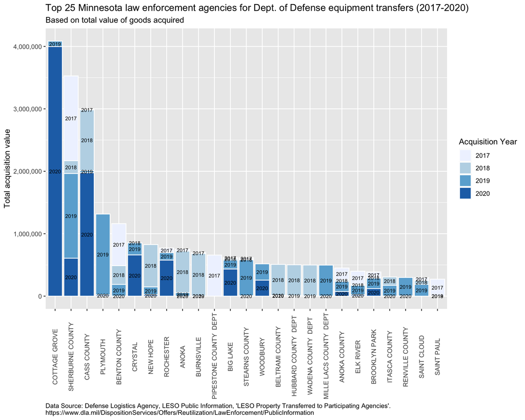

```r
top_acquiring_agencies <- equipment_transfers %>%
  group_by(station_name_LEA) %>%
  summarise(sum_total_acquisitions = sum(acquisition_value)) %>%
  top_n(25) %>%
  arrange(desc(sum_total_acquisitions))

equipment_transfers %>%
  filter(station_name_LEA %in% top_acquiring_agencies$station_name_LEA & ship_year >= 2017) %>%
  mutate(station_name_LEA = factor(station_name_LEA, levels=top_acquiring_agencies$station_name_LEA)) %>%
  group_by(station_name_LEA, ship_year) %>%
  summarise(sum_total_acquisitions = sum(acquisition_value)) %>%
ggplot(., aes(x=station_name_LEA, y=sum_total_acquisitions, fill=as.factor(ship_year))) +
  geom_bar(stat="identity", position="stack", color="#ffffff") +
  geom_text(aes(label=ship_year), position = position_stack(vjust = 0.5), size=2.5) +
  scale_fill_brewer(palette = "Blues", name = "Acquisition Year") +
  scale_y_continuous(label=comma) +
  xlab(NULL) +
  ylab("Total acquisition value") +
  labs(title=sprintf("Top 25 %s law enforcement agencies for Dept. of Defense equipment transfers (%s-%s)", state, min_year, max_year),
       subtitle="Based on total value of goods acquired",
       caption="Data Source: Defense Logistics Agency, LESO Public Information, 'LESO Property Transferred to Participating Agencies'.\nhttps://www.dla.mil/DispositionServices/Offers/Reutilization/LawEnforcement/PublicInformation") +
  theme(axis.text.x = element_text(angle = 90, vjust = 0.5),
        plot.caption = element_text(hjust = 0))
```

What are the most popular items across all agencies in the state?

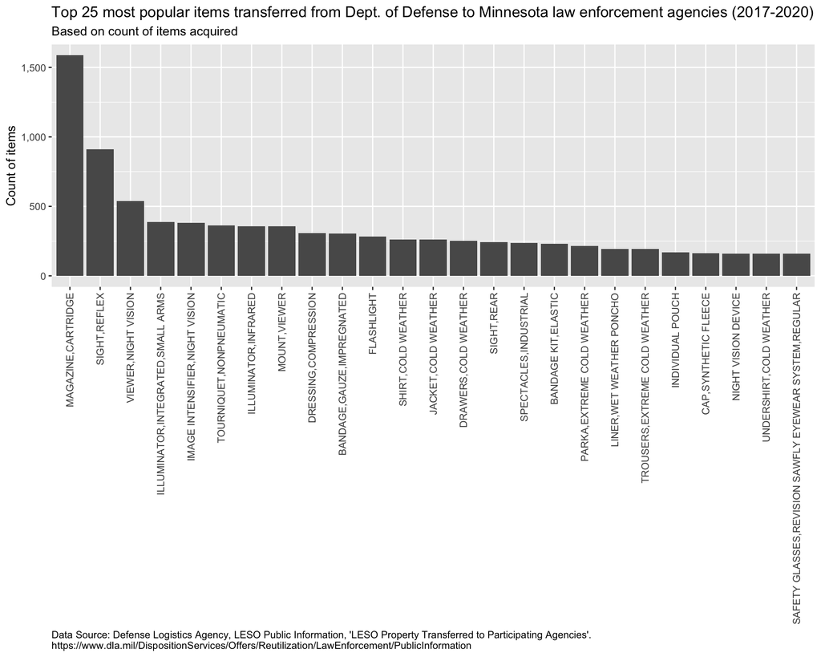

```r
equipment_transfers %>%
  group_by(item_name) %>%
  summarise(count = sum(quantity)) %>%
  arrange(desc(count)) %>%
  top_n(25) %>%
ggplot(., aes(x=reorder(item_name, -count), y=count)) +
  geom_bar(stat="identity") +
  scale_y_continuous(label=comma) +
  xlab(NULL) +
  ylab('Count of items') +
  labs(title=sprintf("Top 25 most popular items transferred from Dept. of Defense to %s law enforcement agencies (%s-%s)", state, min_year, max_year),
       subtitle="Based on count of items acquired",
       caption="Data Source: Defense Logistics Agency, LESO Public Information, 'LESO Property Transferred to Participating Agencies'.\nhttps://www.dla.mil/DispositionServices/Offers/Reutilization/LawEnforcement/PublicInformation") +
  theme(axis.text.x = element_text(angle = 90, vjust = 0.5, hjust = 1),
        plot.caption = element_text(hjust = 0))
```

What are the “big ticket” items across all agencies in the state?

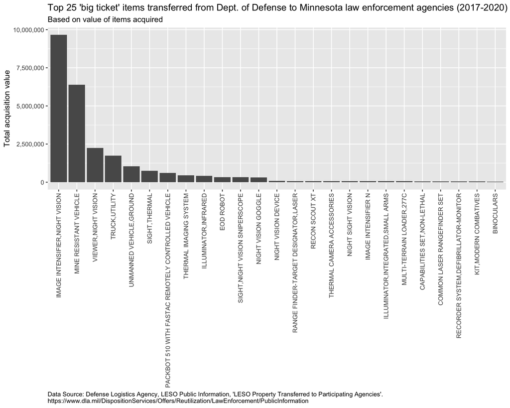

```r
equipment_transfers %>%
  group_by(item_name) %>%
  summarise(sum_acquisition_value = sum(acquisition_value)) %>%
  arrange(desc(sum_acquisition_value)) %>%
  top_n(25) %>%
ggplot(., aes(x=reorder(item_name, -sum_acquisition_value), y=sum_acquisition_value)) +
  geom_bar(stat="identity") +
  scale_y_continuous(label=comma) +
  xlab(NULL) +
  ylab('Total acquisition value') +
  labs(title=sprintf("Top 25 'big ticket' items transferred from Dept. of Defense to %s law enforcement agencies (%s-%s)", state, min_year, max_year),
       subtitle="Based on value of items acquired",
       caption="Data Source: Defense Logistics Agency, LESO Public Information, 'LESO Property Transferred to Participating Agencies'.\nhttps://www.dla.mil/DispositionServices/Offers/Reutilization/LawEnforcement/PublicInformation") +
  theme(axis.text.x = element_text(angle = 90, vjust = 0.5, hjust = 1),
        plot.caption = element_text(hjust = 0))
```

## Surveillance equipment & military-grade vehicles

How many agencies have received sensory-enhancing equipment such as radar, vision, or sound-related equipment? The range of items in this dataset is very broad, so to more quickly pinpoint equipment within a specific category, we can take advantage of the NATO stock number (NSN) information in the dataset. The first four digits in this field correspond to a [‘federal supply classification’ (FSC)](https://www.iso-group.com/Information/FSC/) number, which groups items together into convenient categories. The categories are relatively broadly defined, so some of the items listed within a category may be smaller, accessory-type items that are of less interest for our analysis. We can try to filter out some of the more obvious accessory items (batteries, mounts, etc.) to remove some of this ‘noise’.

The code below uses NSN/FSC numbers to filter for specific categories of sensory-enhancing and potentially surveillance-related items. The dot chart shows how many separate agencies across the state have obtained these different types of items in a given year:

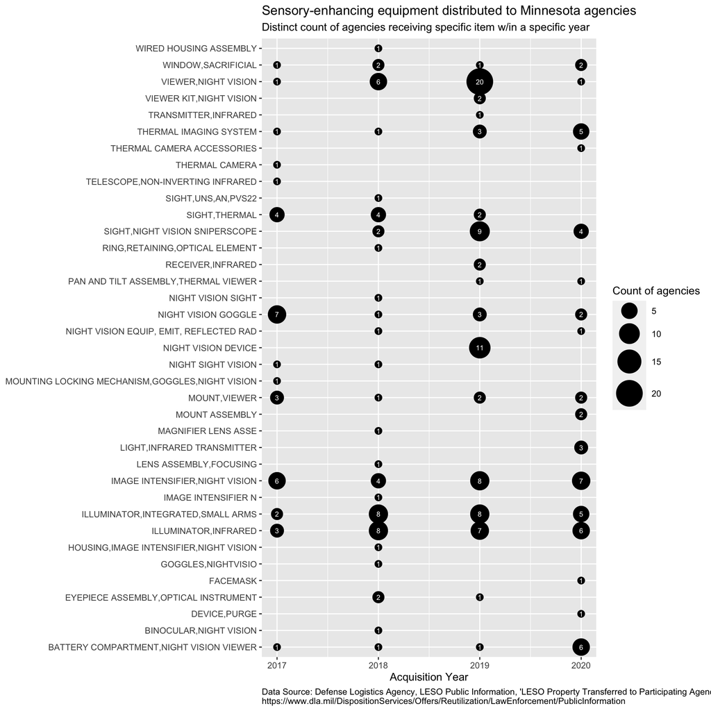

```r
equipment_transfers %>%
  filter(substr(nsn, 1, 4) %in%
           c(
             '5840', # Radar Equipment, Except Airborne
             '5841', # Radar Equipment, Airborne
             '5845', # Underwater Sound Equipment
             '5855' # Night Vision Equipment, Emitted and Reflected Radiation
             )
         ) %>%
  #filter(!(str_detect(item_name, '(BATTERY)|(MOUNT)|(ASSEMBLY)'))) %>% # filter out items that are likely 'accessories'
  filter(!(demil_code == 'A')) %>%
  group_by(item_name, ship_year) %>%
  summarise(sum_acquisition_value = sum(acquisition_value),
            acquiring_agencies = paste(unique(station_name_LEA), collapse="\n"),
            count_of_agencies = length(unique(station_name_LEA))) %>%
ggplot(., aes(x=ship_year, y=item_name)) +
  geom_point(aes(size=count_of_agencies)) +
  geom_text(aes(label=count_of_agencies), size=2.5, color="#ffffff") +
  scale_size(name = "Count of agencies", range = c(3, 12)) +
  ylab(NULL) +
  xlab('Acquisition Year') +
  labs(title=sprintf("Sensory-enhancing equipment distributed to %s agencies", state),
       subtitle="Distinct count of agencies receiving specific item w/in a specific year",
       caption="Data Source: Defense Logistics Agency, LESO Public Information, 'LESO Property Transferred to Participating Agencies'.\nhttps://www.dla.mil/DispositionServices/Offers/Reutilization/LawEnforcement/PublicInformation") +
  theme(plot.caption = element_text(hjust = 0))
```

How many agencies have received military-grade and remote-controlled vehicles? The code below again uses NSN/FSC numbers to filter for specific categories of military-grade and remote-controlled vehicles. The dot chart shows how many separate agencies across the state have obtained these different types of items in a given year:

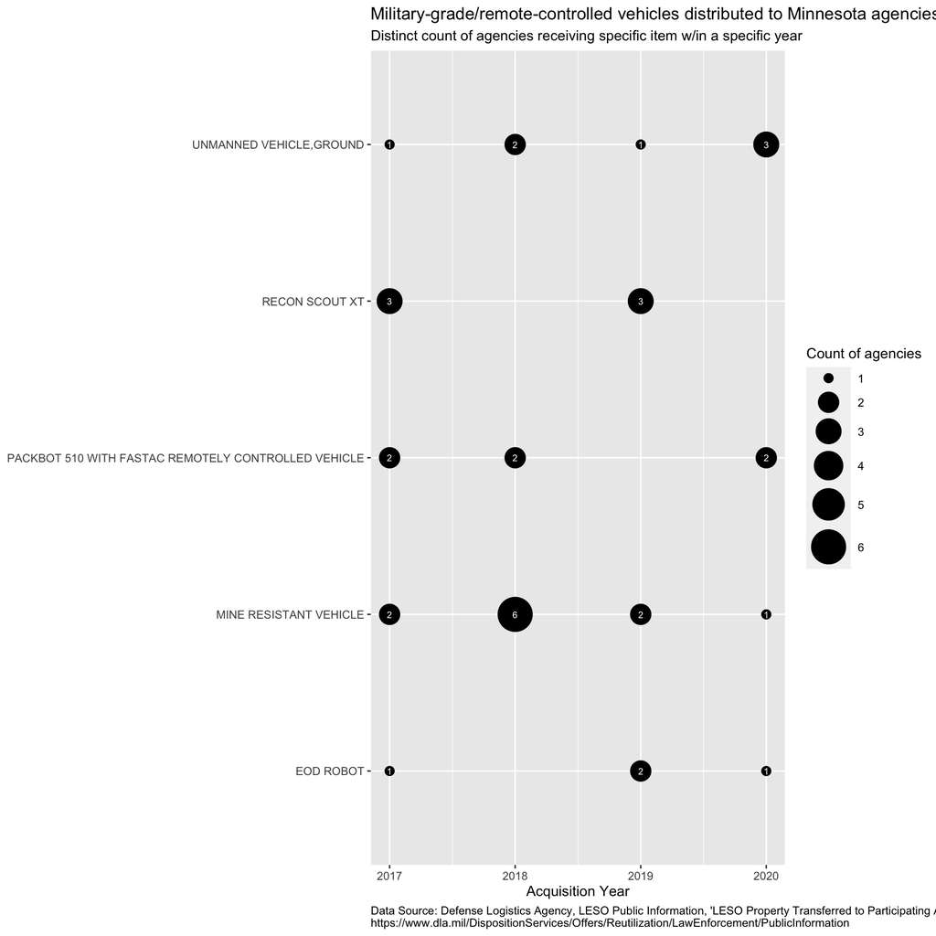

```r
equipment_transfers %>%
  filter(substr(nsn, 1, 4) %in%
           c(
             '1385', # Surface Use Explosive Ordnance Disposal Tools and Equipment
             '1510', # Aircraft, Fixed Wing
             '1520', # Aircraft, Rotary Wing
             '1550', # Unmanned Aircraft
             '2350', # Combat, Assault, and Tactical Vehicles, Tracked
             '2355', # Combat, Assault, and Tactical Vehicles, Wheeled
             '2360' # Not in FSC codes list, but contains examples of 'Unmanned vehicles'
           )
         ) %>%
  group_by(item_name, ship_year) %>%
  summarise(sum_acquisition_value = sum(acquisition_value),
            acquiring_agencies = paste(unique(station_name_LEA), collapse="\n"),
            count_of_agencies = length(unique(station_name_LEA))) %>%
ggplot(., aes(x=ship_year, y=item_name)) +
  geom_point(aes(size=count_of_agencies)) +
  geom_text(aes(label=count_of_agencies), size=2.5, color="#ffffff") +
  scale_size(name = "Count of agencies", range = c(3, 12)) +
  ylab(NULL) +
  xlab('Acquisition Year') +
  labs(title=sprintf("Military-grade/remote-controlled vehicles distributed to %s agencies", state),
       subtitle="Distinct count of agencies receiving specific item w/in a specific year",
       caption="Data Source: Defense Logistics Agency, LESO Public Information, 'LESO Property Transferred to Participating Agencies'.\nhttps://www.dla.mil/DispositionServices/Offers/Reutilization/LawEnforcement/PublicInformation") +
  theme(plot.caption = element_text(hjust = 0))
```

## References

**Dataset:**

- Defense Logistics Agency, [“LESO Public Information”](https://www.dla.mil/DispositionServices/Offers/Reutilization/LawEnforcement/PublicInformation/)

**Additional references:**

- Barret, B. (02 June 2020). *Wired.* [“The Pentagon’s Hand-Me-Downs Helped Militarize Police. Here’s How.”](https://www.wired.com/story/pentagon-hand-me-downs-militarize-police-1033-program/)
- Defense Logistics Agency, [“1033 Program FAQs”](https://www.dla.mil/DispositionServices/Offers/Reutilization/LawEnforcement/ProgramFAQs.aspx)
- Institute for Transparent Policing, [Project 1033](https://project1033.org/)